# Tweet_Sentiment_Extractio_EDA

#### Introduction -:

Sentiment Analysis can be defined as the process of analyzing text data and categorizing them into Positive, Negative, or Neutral sentiments. Sentiment Analysis is used in many cases like Social Media Monitoring, Customer service, Brand Monitoring, political campaigns, etc.. Its Kaggle competition to find Tweet's Sentiment analysis .

Refrence:-https://www.kaggle.com/c/tweet-sentiment-extraction

#### Business problem: -

1. Analyzing customer feedback such as social media conversations, product reviews, and survey responses allows companies to understand the customer’s emotions better which is becoming more essential to meet their needs.
2. In this problem, we are given some text data along with their sentiment(positive/negative/neutral) and we need to find the phrases/words that best supports the sentiment.
3. Using Deep Learning on training data (text and sentiment) have to predict selected_text(Phrase).

```python
import pandas as pd
import warnings
warnings.filterwarnings('ignore')
import numpy as np
import matplotlib.pyplot as plt
import seaborn as sns
from wordcloud import WordCloud
import nltk
from nltk.corpus import stopwords
nltk.download('punkt')
nltk.download('stopwords')
import string
```

```python
from google.colab import drive
drive.mount('/content/drive')
```

```python
#Load and read train csv data
train_data=pd.read_csv('/content/drive/MyDrive/TweetData/train.csv')
train_data.head(10)
```

|  | textID | text | selected_text | sentiment |
| --- | --- | --- | --- | --- |
| 0 | cb774db0d1 | I`d have responded, if I were going | I`d have responded, if I were going | neutral |
| 1 | 549e992a42 | Sooo SAD I will miss you here in San Diego!!! | Sooo SAD | negative |
| 2 | 088c60f138 | my boss is bullying me... | bullying me | negative |
| 3 | 9642c003ef | what interview! leave me alone | leave me alone | negative |
| 4 | 358bd9e861 | Sons of ****, why couldn`t they put them on t... | Sons of ****, | negative |
| 5 | 28b57f3990 | http://www.dothebouncy.com/smf - some shameles... | http://www.dothebouncy.com/smf - some shameles... | neutral |
| 6 | 6e0c6d75b1 | 2am feedings for the baby are fun when he is a... | fun | positive |
| 7 | 50e14c0bb8 | Soooo high | Soooo high | neutral |
| 8 | e050245fbd | Both of you | Both of you | neutral |
| 9 | fc2cbefa9d | Journey!? Wow... u just became cooler. hehe.... | Wow... u just became cooler. | positive |

```python
#Load and read test csv data
test_data=pd.read_csv('/content/drive/MyDrive/TweetData/test.csv')
test_data.head(5)
```

|  | textID | text | sentiment |
| --- | --- | --- | --- |
| 0 | f87dea47db | Last session of the day http://twitpic.com/67ezh | neutral |
| 1 | 96d74cb729 | Shanghai is also really exciting (precisely -... | positive |
| 2 | eee518ae67 | Recession hit Veronique Branquinho, she has to... | negative |
| 3 | 01082688c6 | happy bday! | positive |
| 4 | 33987a8ee5 | http://twitpic.com/4w75p - I like it!! | positive |

```python
print("Train Data Shape",train_data.shape)
print("Test Data Shape",test_data.shape)
```

```
Train Data Shape (27481, 4)
Test Data Shape (3534, 3)
```

## Exploratory Data Analysis

```python
#Checking Null Value on train data
train_data.isnull().sum()
```

```
textID           0
text             1
selected_text    1
sentiment        0
dtype: int64
```

```python
train_data.dropna(inplace=True)#Removibg null value
# remove own index with default index
train_data.reset_index(inplace = True, drop = True)
```

We found train data's column text and selected_text have null value.

```python
#Checking Null Value  on test data
test_data.isnull().sum()
```

```
textID       0
text         0
sentiment    0
dtype: int64
```

Test data does not have any null value.

```python
train_data["sentiment"].value_counts(normalize=True)
```

```
neutral     0.404549
positive    0.312300
negative    0.283151
Name: sentiment, dtype: float64
```

Here we can see about 40% of the tweets are neutral ,31% positive and 28% negative tweets.

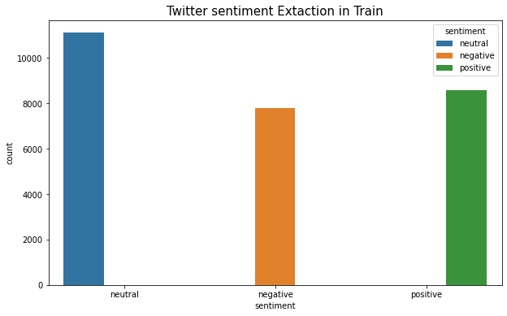

```python
plt.figure(figsize=(10,6))
sns.countplot(x ='sentiment', hue = "sentiment", data = train_data)
plt.title('Twitter sentiment Extaction in Train', fontsize=15)
# Show the plot
plt.show()
```

```python
test_data["sentiment"].value_counts(normalize=True)
```

```
neutral     0.404641
positive    0.312111
negative    0.283248
Name: sentiment, dtype: float64
```

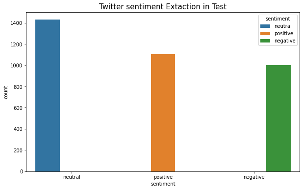

```python
#Test data
plt.figure(figsize=(10,6))
sns.countplot(x ='sentiment', hue = "sentiment", data = test_data)
plt.title('Twitter sentiment Extaction in Test', fontsize=15)
# Show the plot
plt.show()
```

I will seprate the train and test data based on Sentiment categorys(will get Neutral,Positive,Negative category data) and will do indivisual EDA on Sentiment's category data.

```python
# EDA on Train data based on Sentiment's category (neutral)
Neutral_df=train_data[train_data["sentiment"]=="neutral"]
print("Number of Neutral Sentiment on train data=",Neutral_df.shape[0])
```

```
Number of Neutral Sentiment on train data= 11117
```

```python
Neutral_df.head(5)
```

|  | textID | text | selected_text | sentiment |
| --- | --- | --- | --- | --- |
| 0 | cb774db0d1 | I`d have responded, if I were going | I`d have responded, if I were going | neutral |
| 5 | 28b57f3990 | http://www.dothebouncy.com/smf - some shameles... | http://www.dothebouncy.com/smf - some shameles... | neutral |
| 7 | 50e14c0bb8 | Soooo high | Soooo high | neutral |
| 8 | e050245fbd | Both of you | Both of you | neutral |
| 10 | 2339a9b08b | as much as i love to be hopeful, i reckon the... | as much as i love to be hopeful, i reckon the ... | neutral |

We can see most of word(text column) sentence seems similar to "selected_text" aslo we can use Jaccard Similarity to measeure similarty between text and selected_text

```python
#https://studymachinelearning.com/jaccard-similarity-text-similarity-metric-in-nlp/
#https://towardsdatascience.com/overview-of-text-similarity-metrics-3397c4601f50
def Jaccard_Similarity(doc1, doc2):

    # List the unique words in a document
    words_doc1 = set(doc1.lower().split())
    words_doc2 = set(doc2.lower().split())

    # Find the intersection of words list of doc1 & doc2
    intersection = words_doc1.intersection(words_doc2)

    # Find the union of words list of doc1 & doc2
    union = words_doc1.union(words_doc2)

    # Calculate Jaccard similarity score
    # using length of intersection set divided by length of union set
    return float(len(intersection)) / len(union)
```

```python
#https://www.kaggle.com/c/tweet-sentiment-extraction/discussion/138520
#Checking Jaccard_Similarity between text and selected text on nuteral sentiment
results_jaccard=[]

for ind,row in Neutral_df.iterrows():
    sentence1 = row.text
    sentence2 = row.selected_text

    jaccard_score = Jaccard_Similarity(sentence1,sentence2)
    results_jaccard.append([sentence1,sentence2,jaccard_score])
```

```python
jaccard = pd.DataFrame(results_jaccard,columns=["text","selected_text","jaccard_score"])
Neutral_df = Neutral_df.merge(jaccard,how='outer')
```

```python
Neutral_df['Num_words_ST'] = Neutral_df['selected_text'].apply(lambda x:len(str(x).split())) #Number Of words in Selected Text
Neutral_df['Num_word_text'] = Neutral_df['text'].apply(lambda x:len(str(x).split())) #Number Of words in main text
Neutral_df['difference_in_words'] = Neutral_df['Num_word_text'] - Neutral_df['Num_words_ST'] #Diffrence
```

```python
Neutral_df.head(5)
```

|  | textID | text | selected_text | sentiment | jaccard_score | Num_words_ST | Num_word_text | difference_in_words |
| --- | --- | --- | --- | --- | --- | --- | --- | --- |
| 0 | cb774db0d1 | I`d have responded, if I were going | I`d have responded, if I were going | neutral | 1.0 | 7 | 7 | 0 |
| 1 | 28b57f3990 | http://www.dothebouncy.com/smf - some shameles... | http://www.dothebouncy.com/smf - some shameles... | neutral | 1.0 | 12 | 12 | 0 |
| 2 | 50e14c0bb8 | Soooo high | Soooo high | neutral | 1.0 | 2 | 2 | 0 |
| 3 | e050245fbd | Both of you | Both of you | neutral | 1.0 | 3 | 3 | 0 |
| 4 | 2339a9b08b | as much as i love to be hopeful, i reckon the... | as much as i love to be hopeful, i reckon the ... | neutral | 1.0 | 23 | 23 | 0 |

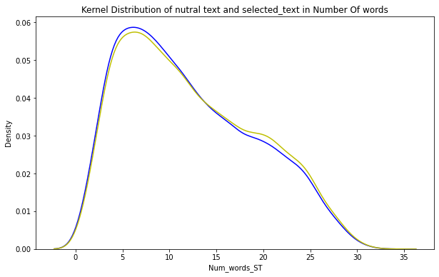

```python
plt.figure(figsize=(10,6))
p1=sns.kdeplot(Neutral_df['Num_words_ST'],  color="b").set_title('Kernel Distribution of nutral text and selected_text in Number Of words')
p1=sns.kdeplot(Neutral_df['Num_word_text'], color="y")
plt.show()
```

- We can see that text and selected text has same distribution as both are overlapping eachother. its mean noth have same length word and also get jaccard score near to 1.
- Also we can observed most of selected_text and text word count range between 5 to 15 and max upto 30 word count.

```python
Neutral_df["jaccard_score"].value_counts()
#As we can see Neutral jacard score have 148 score which is not all belog to  1.0
```

```
1.000000    10012
0.857143       52
0.750000       50
0.875000       49
0.800000       48
            ...
0.640000        1
0.230769        1
0.411765        1
0.240000        1
0.608696        1
Name: jaccard_score, Length: 148, dtype: int64
```

```python
Neutral_df[Neutral_df["jaccard_score"]<0.9]
```

|  | textID | text | selected_text | sentiment | jaccard_score | Num_words_ST | Num_word_text | difference_in_words |
| --- | --- | --- | --- | --- | --- | --- | --- | --- |
| 12 | 4f5267ad70 | Thats it, its the end. Tears for Fears vs Eric... | Thats it, its the end. Tears for Fears | neutral | 0.571429 | 8 | 14 | 6 |
| 23 | 6086b1f016 | will be back later. http://plurk.com/p/rp3k7 | will be back later. | neutral | 0.800000 | 4 | 5 | 1 |
| 40 | a3de81e1ba | Hi how are you doing ??? *just joined twitt... | Hi how are you doing ??? *just joined twitte... | neutral | 0.800000 | 9 | 9 | 0 |
| 46 | 9c4817f73b | if u have a friendster add me!!!!!!!!! ... | if u have a friendster add me!!!!!!!!! ... | neutral | 0.800000 | 15 | 18 | 3 |
| 76 | 32e4ffe225 | _420 why baby? | why baby? | neutral | 0.666667 | 2 | 3 | 1 |
| ... | ... | ... | ... | ... | ... | ... | ... | ... |
| 10971 | 6e07eb34b4 | Link ! | Link | neutral | 0.500000 | 1 | 2 | 1 |
| 11040 | 6cf2428a33 | I`m like so upset with you.. haha.. you never... | I`m like so upset with you.. haha.. | neutral | 0.538462 | 7 | 13 | 6 |
| 11054 | 3a9d357027 | haha i see im so bored rite now.. it seems li... | haha i see im so bored rite now. | neutral | 0.368421 | 8 | 18 | 10 |
| 11073 | b49385ebb7 | says Finally, Im home. http://plurk.com/p/rr121 | says Finally, Im home. | neutral | 0.800000 | 4 | 5 | 1 |
| 11116 | 6f7127d9d7 | All this flirting going on - The ATG smiles... | All this flirting going on - The ATG smiles. Y... | neutral | 0.833333 | 11 | 11 | 0 |

751 rows × 8 columns

kept threshold 0.9 considring above 0.9 slighty would be same to selected _text While filtring jacard score we got 751 text datapoint which is not same to selected text.

```python
# EDA on Train data based on Sentiment's category (Positive)
Positive_df=train_data[train_data["sentiment"]=="positive"]
print("Number of positive Sentiment on train data=",Positive_df.shape[0])
```

```
Number of positive Sentiment on train data= 8582
```

```python
#Checking Jaccard_Similarity between text and selected text on positive sentiment
#https://www.kaggle.com/c/tweet-sentiment-extraction/discussion/138520
results_jaccard=[]

for ind,row in Positive_df.iterrows():
    sentence1 = row.text
    sentence2 = row.selected_text

    jaccard_score = Jaccard_Similarity(sentence1,sentence2)
    results_jaccard.append([sentence1,sentence2,jaccard_score])
```

```python
jaccard_pos = pd.DataFrame(results_jaccard,columns=["text","selected_text","jaccard_score"])
Positive_df = Positive_df.merge(jaccard_pos,how='outer')
```

```python
Positive_df['Num_words_ST'] = Positive_df['selected_text'].apply(lambda x:len(str(x).split())) #Number Of words in Selected Text
Positive_df['Num_word_text'] = Positive_df['text'].apply(lambda x:len(str(x).split())) #Number Of words in main text
Positive_df['difference_in_words'] = Positive_df['Num_word_text'] - Positive_df['Num_words_ST'] #Diffrence
```

```python
Positive_df.head(5)
```

|  | textID | text | selected_text | sentiment | jaccard_score | Num_words_ST | Num_word_text | difference_in_words |
| --- | --- | --- | --- | --- | --- | --- | --- | --- |
| 0 | 6e0c6d75b1 | 2am feedings for the baby are fun when he is a... | fun | positive | 0.071429 | 1 | 14 | 13 |
| 1 | fc2cbefa9d | Journey!? Wow... u just became cooler. hehe.... | Wow... u just became cooler. | positive | 0.500000 | 5 | 10 | 5 |
| 2 | 16fab9f95b | I really really like the song Love Story by Ta... | like | positive | 0.100000 | 1 | 11 | 10 |
| 3 | e48b0b8a23 | Playing Ghost Online is really interesting. Th... | interesting. | positive | 0.043478 | 1 | 24 | 23 |
| 4 | e00c6ef376 | the free fillin` app on my ipod is fun, im add... | the free fillin` app on my ipod is fun, im add... | positive | 1.000000 | 11 | 11 | 0 |

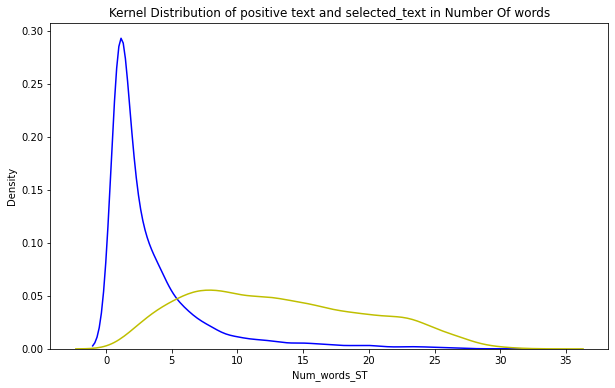

```python
plt.figure(figsize=(10,6))#ploting PDF
p1=sns.kdeplot(Positive_df['Num_words_ST'],  color="b").set_title('Kernel Distribution of positive text and selected_text in Number Of words')
p1=sns.kdeplot(Positive_df['Num_word_text'], color="y")
plt.show()
```

- We can see that text and selected text has big diffrence distribution. in this case select_text is not as same as text.
- Also we can observed most of selected_text word count range between 0 to 5 and text range 5 to 20.

```python
Positive_df[Positive_df["jaccard_score"]==1.0]
```

|  | textID | text | selected_text | sentiment | jaccard_score | Num_words_ST | Num_word_text | difference_in_words |
| --- | --- | --- | --- | --- | --- | --- | --- | --- |
| 4 | e00c6ef376 | the free fillin` app on my ipod is fun, im add... | the free fillin` app on my ipod is fun, im add... | positive | 1.0 | 11 | 11 | 0 |
| 12 | d8ba2a99a9 | romance zero is funny | romance zero is funny | positive | 1.0 | 4 | 4 | 0 |
| 15 | fa2654e730 | Chilliin | Chilliin | positive | 1.0 | 1 | 1 | 0 |
| 17 | bbbc46889b | THANK YYYYYYYYYOOOOOOOOOOUUUUU! | THANK YYYYYYYYYOOOOOOOOOOUUUUU! | positive | 1.0 | 2 | 2 | 0 |
| 19 | 3d2fcd78c8 | Happy Star Wars day everyone! and Enjoy the ho... | Happy Star Wars day everyone! and Enjoy the ho... | positive | 1.0 | 10 | 10 | 0 |
| ... | ... | ... | ... | ... | ... | ... | ... | ... |
| 8556 | 04db7e701e | really really wants to go and see Coraline. | really really wants to go and see Coraline. | positive | 1.0 | 8 | 8 | 0 |
| 8557 | 878acf5421 | i wish you were in my class last year | i wish you were in my class last year | positive | 1.0 | 9 | 9 | 0 |
| 8560 | 2151413f96 | ish okay my loveee | ish okay my loveee | positive | 1.0 | 4 | 4 | 0 |
| 8565 | 0a43c46417 | Really good night | Really good night | positive | 1.0 | 3 | 3 | 0 |
| 8581 | ed167662a5 | But it was worth it ****. | But it was worth it ****. | positive | 1.0 | 6 | 6 | 0 |

1124 rows × 8 columns

While filtring jacard score==1 we got 1124 text datapoint which is same to selected text in positive sentiment

```python
# EDA on Train data based on Sentiment's category (negative)
negative_df=train_data[train_data["sentiment"]=="negative"]
print("Number of negative Sentiment on train data=",negative_df.shape[0])
```

```
Number of negative Sentiment on train data= 7781
```

```python
#Checking Jaccard_Similarity between text and selected text on negative_df sentiment
#https://www.kaggle.com/c/tweet-sentiment-extraction/discussion/138520
results_jaccard=[]

for ind,row in negative_df.iterrows():
    sentence1 = row.text
    sentence2 = row.selected_text

    jaccard_score = Jaccard_Similarity(sentence1,sentence2)
    results_jaccard.append([sentence1,sentence2,jaccard_score])
```

```python
jaccard_ = pd.DataFrame(results_jaccard,columns=["text","selected_text","jaccard_score"])
negative_df = negative_df.merge(jaccard_,how='outer')
```

```python
negative_df['Num_words_ST'] = negative_df['selected_text'].apply(lambda x:len(str(x).split())) #Number Of words in Selected Text
negative_df['Num_word_text'] = negative_df['text'].apply(lambda x:len(str(x).split())) #Number Of words in main text
negative_df['difference_in_words'] = negative_df['Num_word_text'] - negative_df['Num_words_ST'] #Diffrence
```

```python
negative_df.head(5)
```

|  | textID | text | selected_text | sentiment | jaccard_score | Num_words_ST | Num_word_text | difference_in_words |
| --- | --- | --- | --- | --- | --- | --- | --- | --- |
| 0 | 549e992a42 | Sooo SAD I will miss you here in San Diego!!! | Sooo SAD | negative | 0.200000 | 2 | 10 | 8 |
| 1 | 088c60f138 | my boss is bullying me... | bullying me | negative | 0.166667 | 2 | 5 | 3 |
| 2 | 9642c003ef | what interview! leave me alone | leave me alone | negative | 0.600000 | 3 | 5 | 2 |
| 3 | 358bd9e861 | Sons of ****, why couldn`t they put them on t... | Sons of ****, | negative | 0.214286 | 3 | 14 | 11 |
| 4 | 74a76f6e0a | My Sharpie is running DANGERously low on ink | DANGERously | negative | 0.125000 | 1 | 8 | 7 |

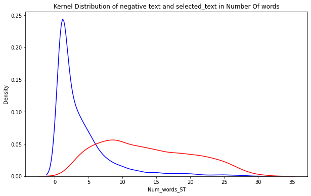

```python
plt.figure(figsize=(10,6))
p1=sns.kdeplot(negative_df['Num_words_ST'],  color="b").set_title('Kernel Distribution of negative text and selected_text in Number Of words')
p1=sns.kdeplot(negative_df['Num_word_text'], color="r")
plt.show()
```

- We can see that text and selected text has big diffrence distribution. in this case select_text is not as same as text.
- Also we can observed most of selected_text word count range between 0 to 5 and text range 5 to 20.

```python
negative_df[negative_df["jaccard_score"]==1.0]
```

|  | textID | text | selected_text | sentiment | jaccard_score | Num_words_ST | Num_word_text | difference_in_words |
| --- | --- | --- | --- | --- | --- | --- | --- | --- |
| 6 | 8a939bfb59 | Uh oh, I am sunburned | Uh oh, I am sunburned | negative | 1.0 | 5 | 5 | 0 |
| 10 | 852edc3769 | I`m sorry. | I`m sorry. | negative | 1.0 | 2 | 2 | 0 |
| 19 | 11084dac09 | it is ****...u have dissappointed me that pas... | it is ****...u have dissappointed me that past... | negative | 1.0 | 10 | 10 | 0 |
| 23 | 2a9765b7f9 | I give in to easily | I give in to easily | negative | 1.0 | 5 | 5 | 0 |
| 26 | 0a61cbf4b5 | I am sooo tired | I am sooo tired | negative | 1.0 | 4 | 4 | 0 |
| ... | ... | ... | ... | ... | ... | ... | ... | ... |
| 7750 | ea7bc30d23 | Killed a pigeon today Thought it was going to... | Killed a pigeon today Thought it was going to... | negative | 1.0 | 28 | 28 | 0 |
| 7756 | 521d5dd501 | I bet you received lots of hit from that twee... | I bet you received lots of hit from that tweet... | negative | 1.0 | 17 | 17 | 0 |
| 7763 | 0d46954e4d | WHY DO I EVEN TRY... WHEN DEEP DOWN INSIDE I K... | WHY DO I EVEN TRY... WHEN DEEP DOWN INSIDE I K... | negative | 1.0 | 17 | 17 | 0 |
| 7766 | bafc9b3f4f | Wow. So I hate Staples right now. Majorly. Tha... | Wow. So I hate Staples right now. Majorly. Tha... | negative | 1.0 | 17 | 17 | 0 |
| 7771 | 9057950ae4 | Where is my bestie when i need him | Where is my bestie when i need him | negative | 1.0 | 8 | 8 | 0 |

1143 rows × 8 columns

While filtring jacard score==1 we got 1143 text datapoint which is same to selected text in Negative sentiment

1. Discussion:https://www.kaggle.com/c/tweet-sentiment-extraction/discussion/138520 We know that neutral tweets have a jaccard similarity between text and selected_text
2. Jaccard for each sentiment Positive=31.153452566112183, Negative=33.703535664631374, Neutral=96.95804702715559
3. Also we see distribution between text and selected_text

Word Cloud is a data visualization technique used for representing text data in which the size of each word indicates its frequency or importance. Significant textual data points can be highlighted using a word cloud

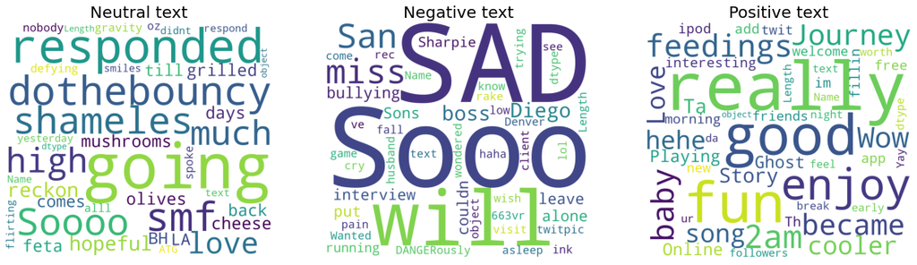

```python
fig, axes = plt.subplots(1,3,figsize=(20,15))

wordcloud = WordCloud(width = 900, height = 800,
                background_color ='white',
                min_font_size = 10).generate(str(Neutral_df['text']))#Neutral sentment text world cloud

axes[0].imshow(wordcloud)
axes[0].axis("off")
axes[0].set_title('Neutral text',fontsize=20)

wordcloud1 = WordCloud(width = 900, height = 800,
                background_color ='white',
                min_font_size = 10).generate(str(negative_df['text']))#Negative sentment text world cloud

axes[1].imshow(wordcloud1)
axes[1].axis("off")
axes[1].set_title('Negative text',fontsize=20)

wordcloud2 = WordCloud(width = 900, height = 800,
                background_color ='white',
                min_font_size = 10).generate(str(Positive_df['text']))#Positive sentment text world cloud


axes[2].imshow(wordcloud2)
axes[2].axis("off")
axes[2].set_title('Positive text',fontsize=20)

# plot the WordCloud image

plt.show()
```

### Text preprocessing

Text preprocessing is a method to clean the text data and make it ready to feed data to the model. Text data contains noise in various forms like emotions, punctuation, text in a different case

```python
#we found some text are  like  "I don`t even remember what's on there!!!"
# I`m like so upset with you.. haha.. you never told me the 411
#have ` this special charector while converting Expand Contractions  its wont recognize the ` this char so inted of this would be
#replace by ' so during converting Expand Contractions it will convert to Contractions like arn't to are not like this.
def removespecifchar(df):
  special_characters = "`"
  for k in range(len(df)):
    if(special_characters in df[k]):
      df[k]=df[k].replace("`","'")
```

```python
#----------------------------Train data ----------------------------------------#
train_data['text'] = removespecifchar(train_data['text'])
train_data['selected_text'] =removespecifchar(train_data['selected_text'])
#----------------------------Test data------------------------------------------#removespecifchar
test_data['text'] = removespecifchar(test_data['text'])
```

#### Expand Contractions

Contraction is the shortened form of a word like don’t stands for do not, aren’t stands for are not. Like this, we need to expand this contraction in the text data for better analysis

```python
#https://github.com/dipanjanS/practical-machine-learning-with-python/blob/master/bonus%20content/nlp%20proven%20approach/contractions.py
CONTRACTION_MAP = {
"ain't": "is not",
"aren't": "are not",
"can't": "cannot",
"can't've": "cannot have",
"'cause": "because",
"could've": "could have",
"couldn't": "could not",
"couldn't've": "could not have",
"didn't": "did not",
"doesn't": "does not",
"don't": "do not",
"hadn't": "had not",
"hadn't've": "had not have",
"hasn't": "has not",
"haven't": "have not",
"he'd": "he would",
"he'd've": "he would have",
"he'll": "he will",
"he'll've": "he he will have",
"he's": "he is",
"how'd": "how did",
"how'd'y": "how do you",
"how'll": "how will",
"how's": "how is",
"I'd": "I would",
"I'd've": "I would have",
"I'll": "I will",
"I'll've": "I will have",
"I'm": "I am",
"I've": "I have",
"i'd": "i would",
"i'd've": "i would have",
"i'll": "i will",
"i'll've": "i will have",
"i'm": "i am",
"i've": "i have",
"isn't": "is not",
"it'd": "it would",
"it'd've": "it would have",
"it'll": "it will",
"it'll've": "it will have",
"it's": "it is",
"let's": "let us",
"ma'am": "madam",
"mayn't": "may not",
"might've": "might have",
"mightn't": "might not",
"mightn't've": "might not have",
"must've": "must have",
"mustn't": "must not",
"mustn't've": "must not have",
"needn't": "need not",
"needn't've": "need not have",
"o'clock": "of the clock",
"oughtn't": "ought not",
"oughtn't've": "ought not have",
"shan't": "shall not",
"sha'n't": "shall not",
"shan't've": "shall not have",
"she'd": "she would",
"she'd've": "she would have",
"she'll": "she will",
"she'll've": "she will have",
"she's": "she is",
"should've": "should have",
"shouldn't": "should not",
"shouldn't've": "should not have",
"so've": "so have",
"so's": "so as",
"that'd": "that would",
"that'd've": "that would have",
"that's": "that is",
"there'd": "there would",
"there'd've": "there would have",
"there's": "there is",
"they'd": "they would",
"they'd've": "they would have",
"they'll": "they will",
"they'll've": "they will have",
"they're": "they are",
"they've": "they have",
"to've": "to have",
"wasn't": "was not",
"we'd": "we would",
"we'd've": "we would have",
"we'll": "we will",
"we'll've": "we will have",
"we're": "we are",
"we've": "we have",
"weren't": "were not",
"what'll": "what will",
"what'll've": "what will have",
"what're": "what are",
"what's": "what is",
"what've": "what have",
"when's": "when is",
"when've": "when have",
"where'd": "where did",
"where's": "where is",
"where've": "where have",
"who'll": "who will",
"who'll've": "who will have",
"who's": "who is",
"who've": "who have",
"why's": "why is",
"why've": "why have",
"will've": "will have",
"won't": "will not",
"won't've": "will not have",
"would've": "would have",
"wouldn't": "would not",
"wouldn't've": "would not have",
"y'all": "you all",
"y'all'd": "you all would",
"y'all'd've": "you all would have",
"y'all're": "you all are",
"y'all've": "you all have",
"you'd": "you would",
"you'd've": "you would have",
"you'll": "you will",
"you'll've": "you will have",
"you're": "you are",
"you've": "you have"
}
```

```python
#https://stackoverflow.com/questions/43018030/replace-apostrophe-short-words-in-python/47091370#47091370
import re
def decontracted(text):
  for word in text.split():
    if word.lower() in CONTRACTION_MAP:
        text = text.replace(word, CONTRACTION_MAP[word.lower()])
    return text
```

```python
#----------------------------Train data ----------------------------------------#
train_data['text'] = train_data['text'].apply(lambda text: decontracted(text))
train_data['selected_text'] = train_data['selected_text'].apply(lambda text: decontracted(text))
#----------------------------Test data------------------------------------------#
test_data['text'] = test_data['text'].apply(lambda text: decontracted(text))
```

#### Remove punctuation

```python
def clean_text(text):
    '''Make text lowercase, remove text in square brackets,remove links,remove punctuation
    and remove words containing numbers.'''
    text = str(text).lower()
    text = re.sub('\[.*?\]', '', text)
    text = re.sub('https?://\S+|www\.\S+', '', text)
    text = re.sub('<.*?>+', '', text)
    text = re.sub('[%s]' % re.escape(string.punctuation), '', text)
    text = re.sub('\n', '', text)
    text = re.sub('\w*\d\w*', '', text)
    return text
```

```python
#----------------------------Train data ----------------------------------------#
train_data['text'] = train_data['text'].apply(lambda text: clean_text(text))
train_data['selected_text'] = train_data['selected_text'].apply(lambda text: clean_text(text))
#----------------------------Test data------------------------------------------#
test_data['text'] = test_data['text'].apply(lambda text: clean_text(text))
```

#### Remove Stop word

```python
STOPWORDS = set(nltk.corpus.stopwords.words('english'))
def cleaning_stopwords(text):
    return " ".join([word for word in str(text).split() if word not in STOPWORDS])
```

```python
#----------------------------Train data ----------------------------------------#
train_data['text'] = train_data['text'].apply(lambda text: cleaning_stopwords(text))
train_data['selected_text'] = train_data['selected_text'].apply(lambda text: cleaning_stopwords(text))
#----------------------------Test data------------------------------------------#
test_data['text'] = test_data['text'].apply(lambda text: cleaning_stopwords(text))
```

Let's create most 20 comman word from all the sentiment.

```python
#https://stackoverflow.com/questions/29903025/count-most-frequent-100-words-from-sentences-in-dataframe-pandas
# neutral sentiment text data
from collections import Counter
count_n=Counter(" ".join(train_data[train_data["sentiment"]=="neutral"]["text"]).split()).most_common(20)
Nuteraltemp = pd.DataFrame(count_n)
Nuteraltemp.columns = ['Common_words','count']
```

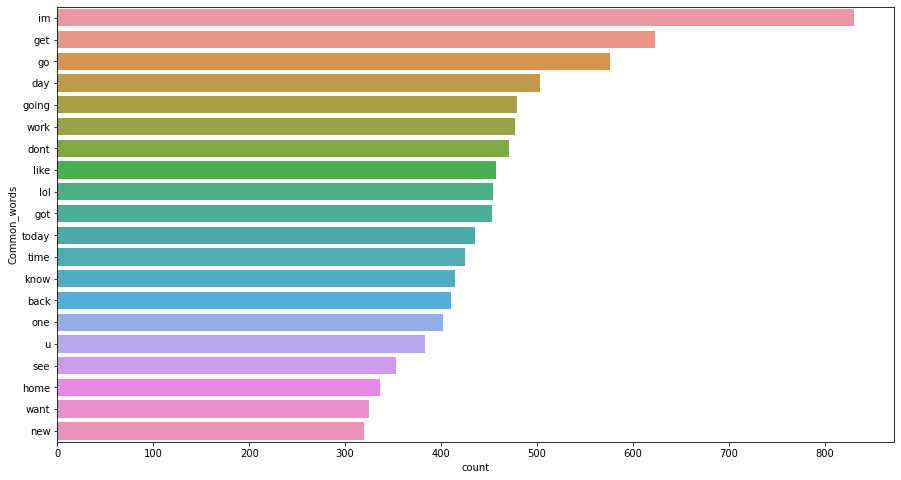

```python
fig,ax=plt.subplots(figsize=(15,8))
sns.barplot(x = 'count',
            y = 'Common_words',
            data = Nuteraltemp)
plt.show()
```

```python
#https://stackoverflow.com/questions/29903025/count-most-frequent-100-words-from-sentences-in-dataframe-pandas
# positive sentiment text data
from collections import Counter
count_n=Counter(" ".join(train_data[train_data["sentiment"]=="positive"]["text"]).split()).most_common(20)
temp = pd.DataFrame(count_n)
temp.columns = ['Common_words','count']
```

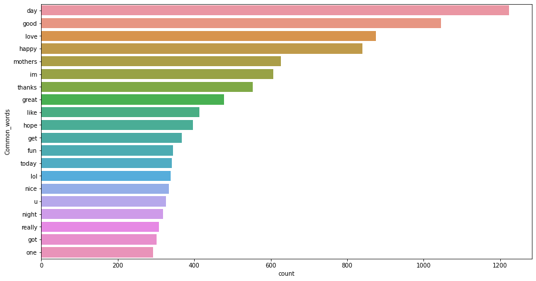

```python
fig,ax=plt.subplots(figsize=(15,8))
sns.barplot(x = 'count',
            y = 'Common_words',
            data = temp)
plt.show()
```

```python
#https://stackoverflow.com/questions/29903025/count-most-frequent-100-words-from-sentences-in-dataframe-pandas
# negative sentiment text data
from collections import Counter
count_n=Counter(" ".join(train_data[train_data["sentiment"]=="negative"]["text"]).split()).most_common(20)
temp = pd.DataFrame(count_n)
temp.columns = ['Common_words','count']
```

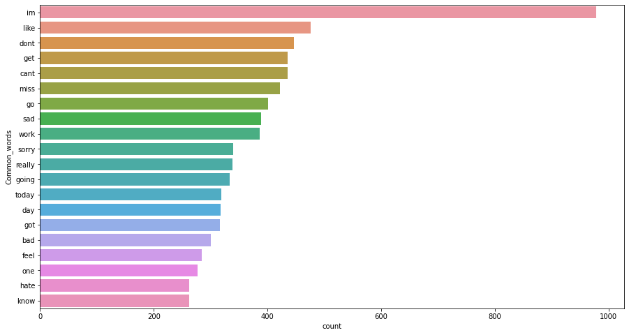

```python
fig,ax=plt.subplots(figsize=(15,8))
sns.barplot(x = 'count',
            y = 'Common_words',
            data = temp)
plt.show()
```